# Pertemuan 2 - Regresi Soal 1

## Metode Hildreth-Lu

Penanganan kedua adalah menggunakan metode Hildreth-Lu. Metode ini akan mencari nilai SSE terkecil dan dapat dicari secara manual maupun menggunakan packages. Jika menggunakan packages, gunakan `library` *packages* `HORM`.

```r
#Penanganan Autokorelasi Hildreth lu
# Hildreth-Lu
hildreth.lu.func<- function(r, model){
  x <- model.matrix(model)[,-1]
  y <- model.response(model.frame(model))
  n <- length(y)
  t <- 2:n
  y <- y[t]-r*y[t-1]
  x <- x[t]-r*x[t-1]

  return(lm(y~x))
}

#Pencariab rho yang meminimumkan SSE
r <- c(seq(0.1,0.9, by= 0.1))
tab <- data.frame("rho" = r, "SSE" = sapply(r, function(i){deviance(hildreth.lu.func(i, model))}))
round(tab, 4)
```

```
##   rho    SSE
## 1 0.1 2.9791
## 2 0.2 2.8105
## 3 0.3 2.7052
## 4 0.4 2.6612
## 5 0.5 2.6749
## 6 0.6 2.7420
## 7 0.7 2.8588
## 8 0.8 3.0265
## 9 0.9 3.2529
```

```r
# Grid search halus (ketelitian 0.001)
rOpt <- seq(0.1, 0.9, by = 0.001)
tabOpt <- data.frame("rho" = rOpt, "SSE" = sapply(rOpt, function(i){deviance(hildreth.lu.func(i, model))}))
head(tabOpt[order(tabOpt$SSE), ])
```

```
##       rho      SSE
## 326 0.425 2.659368
## 327 0.426 2.659370
## 325 0.424 2.659372
## 328 0.427 2.659377
## 324 0.423 2.659382
## 329 0.428 2.659390
```

```r
# Nilai rho optimum
rho_opt <- tabOpt[tabOpt$SSE == min(tabOpt$SSE), "rho"]
rho_opt
```

```
## [1] 0.425
```

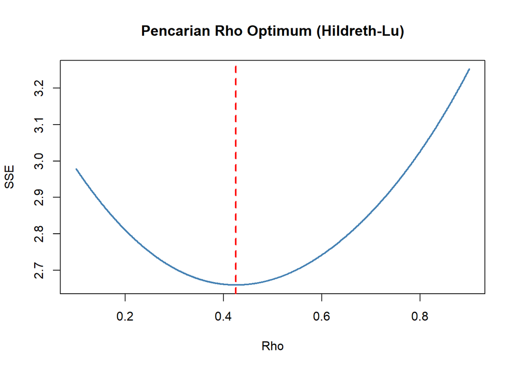

```r
# Grafik SSE optimum
par(mfrow = c(1, 1))
plot(tabOpt$SSE ~ tabOpt$rho, type = "l", col = "steelblue", lwd = 2,
     xlab = "Rho", ylab = "SSE", main = "Pencarian Rho Optimum (Hildreth-Lu)")
abline(v = rho_opt, lty = 2, col = "red", lwd = 2)
```

Perhitungan yang dilakukan aplikasi `R` menunjukkan bahwa nilai $ρ$ optimum, yaitu saat SSE terkecil terdapat pada nilai $ρ=0.425$. Hal tersebut juga ditunjukkan pada plot. Selanjutnya, model dapat didapatkan dengan mengevaluasi nilai $ρ$ ke dalam fungsi `hildreth.lu.func`, serta dilanjutkan dengan pengujian autokorelasi dengan uji Durbin-Watson. Namun, setelah pengecekan tersebut tidak lupa koefisien regresi tersebut digunakan untuk transformasi balik. Persamaan hasil transformasi itulah yang menjadi persamaan sesungguhnya.

```r
# Model terbaik Hildreth-Lu
modelHL <- hildreth.lu.func(rho_opt, model)
summary(modelHL)
```

```
##
## Call:
## lm(formula = y ~ x)
##
## Residuals:
##      Min       1Q   Median       3Q      Max
## -0.55517 -0.25066 -0.05505  0.25010  0.83017
##
## Coefficients:
##             Estimate Std. Error t value Pr(>|t|)
## (Intercept)  15.3655     0.9387   16.37 7.68e-12 ***
## x           -24.0848     1.9380  -12.43 5.88e-10 ***
## ---
## Signif. codes:  0 '***' 0.001 '**' 0.01 '*' 0.05 '.' 0.1 ' ' 1
##
## Residual standard error: 0.3955 on 17 degrees of freedom
## Multiple R-squared:  0.9008, Adjusted R-squared:  0.895
## F-statistic: 154.4 on 1 and 17 DF,  p-value: 5.88e-10
```

```r
# Transformasi Balik
b0_hl <- coef(modelHL)[1] / (1 - rho_opt)
b1_hl <- coef(modelHL)[2]
cat("Persamaan Model Hildreth-Lu:\n")
```

```
## Persamaan Model Hildreth-Lu:
```

```r
cat("y = ", b0_hl, " + (", b1_hl, ") x\n", sep = "")
```

```
## y = 26.72268 + (-24.08484) x
```

Setelah dilakukan tranformasi balik, didapatkan model dengan metode Hildreth-Lu sebagai berikut. y = 26.72268 + (-24.08484) x

```r
#Deteksi autokorelasi
dwtest(modelHL)
```

```
##
##  Durbin-Watson test
##
## data:  modelHL
## DW = 1.9577, p-value = 0.4148
## alternative hypothesis: true autocorrelation is greater than 0
```

```r
# Perbandingan Nilai SSE dan MSE
sseModelawal <- deviance(model)
sseModelCO   <- deviance(modelCOmanual)
sseModelHL   <- deviance(modelHL)

mseModelawal <- sseModelawal / nrow(dtmarket)
mseModelCO   <- sseModelCO / (nrow(dtmarket) - 1)
mseModelHL   <- sseModelHL / (nrow(dtmarket) - 1)

akurasi <- matrix(c(sseModelawal, sseModelCO, sseModelHL,
                    mseModelawal, mseModelCO, mseModelHL),
                  nrow = 2, ncol = 3, byrow = TRUE)
colnames(akurasi) <- c("Model Awal (OLS)", "Model Cochrane-Orcutt", "Model Hildreth-Lu")
row.names(akurasi) <- c("SSE", "MSE")
akurasi
```

```
##     Model Awal (OLS) Model Cochrane-Orcutt Model Hildreth-Lu
## SSE        3.3082574             2.6593681         2.6593683
## MSE        0.1654129             0.1399667         0.1399668
```

Berdasarkan hasil tersebut dapat diketahui bahwa hasil penanganan autokorelasi dengan metode Cochrane-Orcutt dan Hildreth-Lu memiliki nilai SSE yang hampir sama/identik, yaitu sebesar $2.659368$ dan lebih baik dibandingkan model awal ketika autokorelasi masih terjadi, yaitu sebesar $3.3082574$. Hal ini juga terlihat dari nilai MSE yang mengalami penurunan dari $0.1654129$ menjadi $0.1399668$.

# Simpulan